# Sixt Data Science Lab - Test Task for Data Scientist Job Candidates

## Introduction

In this test task you will have an opportunity to demonstrate your skills of a Data Scientist from various angles - processing data, analyzing and vizalizing it, finding insights, applying predictive techniques and explaining your reasoning about it.

The task is based around a bike sharing dataset openly available at UCI Machine Learning Repository [1].

Please go through the steps below, build up the necessary code and comment on your choices.

## Part 1 - Data Loading and Environment Preparation

**Tasks:**

1. Prepare a Python 3 virtual environment (with virtualenv command). requirements.txt output of pip freeze command should be included as part of your submission.
2. Load the data from UCI Repository and put it into the same folder with the notebook. The link to it is https://archive.ics.uci.edu/ml/datasets/bike+sharing+dataset . Here is an available mirror in case the above website is down: https://data.world/uci/bike-sharing-dataset
3. We split the data into two parts. One dataset containing the last 30 days and one dataset with the rest.

**We will do the data split in Task 3 for testing the prediction model**

### **➡️ Part 1 - Task 1:** Python 3 virtual environment

```python
# Install virtualenv if needed
!pip install virtualenv

# Create a virtual environment (you can rename 'env_sixt' as needed)
!virtualenv env_sixt

# Activate the environment

# On macOS/Linux:
# source env_sixt/bin/activate

# On Windows:
!env_sixt\Scripts\activate

!pip freeze > requirements.txt
```

```
created virtual environment CPython3.11.13.final.0-64 in 295ms
  creator CPython3Posix(dest=/content/env_sixt, clear=False, no_vcs_ignore=False, global=False)
  seeder FromAppData(download=False, pip=bundle, setuptools=bundle, via=copy, app_data_dir=/root/.local/share/virtualenv)
    added seed packages: pip==25.1.1, setuptools==80.3.1
  activators BashActivator,CShellActivator,FishActivator,NushellActivator,PowerShellActivator,PythonActivator
```

## Part 2 - Data Processing and Analysis

**Tasks:**

1. Perform all needed steps to load and clean the data. Please comment the major steps of your code.
2. Visualise rentals of bikes per day.
3. Assume that each bike has exactly maximum 12 rentals per day.
   - Find the maximum number of bicycles `nmax` that was needed in any one day.
   - Find the 95%-percentile of bicycles `n95` that was needed in any one day.
4. Visualize the distribution of the covered days depending on the number of available bicycles (e.g. `nmax` bicycles would cover 100% of days, `n95` covers 95%, etc.)

**Answers / comments / reasoning:**

### **➡️ Part 2 - Task 1:** Loading and cleaning the dataset

```python
import pandas as pd

# !wget https://archive.ics.uci.edu/static/public/275/bike+sharing+dataset.zip
# !unzip bike+sharing+dataset.zip

df = pd.read_csv('day.csv')
print(f"Loaded {df.shape[0]} rows and {df.shape[1]} columns.")
# Preview the dataset
df.sample(10)
```

```
Loaded 731 rows and 16 columns.
```

|  | instant | dteday | season | yr | mnth | holiday | weekday | workingday | weathersit | temp | atemp | hum | windspeed | casual | registered | cnt |
| --- | --- | --- | --- | --- | --- | --- | --- | --- | --- | --- | --- | --- | --- | --- | --- | --- |
| 568 | 569 | 2012-07-22 | 3 | 1 | 7 | 0 | 0 | 0 | 2 | 0.667500 | 0.623125 | 0.762500 | 0.093921 | 2544 | 4866 | 7410 |
| 657 | 658 | 2012-10-19 | 4 | 1 | 10 | 0 | 5 | 1 | 2 | 0.563333 | 0.537896 | 0.815000 | 0.134954 | 753 | 4671 | 5424 |
| 135 | 136 | 2011-05-16 | 2 | 0 | 5 | 0 | 1 | 1 | 1 | 0.577500 | 0.550512 | 0.787917 | 0.126871 | 773 | 3185 | 3958 |
| 64 | 65 | 2011-03-06 | 1 | 0 | 3 | 0 | 0 | 0 | 2 | 0.376522 | 0.366252 | 0.948261 | 0.343287 | 114 | 491 | 605 |
| 234 | 235 | 2011-08-23 | 3 | 0 | 8 | 0 | 2 | 1 | 1 | 0.640833 | 0.606067 | 0.455417 | 0.146763 | 1281 | 4614 | 5895 |
| 463 | 464 | 2012-04-08 | 2 | 1 | 4 | 0 | 0 | 0 | 1 | 0.500000 | 0.492425 | 0.275833 | 0.232596 | 2230 | 2939 | 5169 |
| 58 | 59 | 2011-02-28 | 1 | 0 | 2 | 0 | 1 | 1 | 2 | 0.407273 | 0.400118 | 0.876364 | 0.289686 | 81 | 1365 | 1446 |
| 407 | 408 | 2012-02-12 | 1 | 1 | 2 | 0 | 0 | 0 | 1 | 0.127500 | 0.101658 | 0.464583 | 0.409212 | 73 | 1456 | 1529 |
| 513 | 514 | 2012-05-28 | 2 | 1 | 5 | 1 | 1 | 0 | 1 | 0.712500 | 0.679300 | 0.676250 | 0.196521 | 2557 | 3486 | 6043 |
| 690 | 691 | 2012-11-21 | 4 | 1 | 11 | 0 | 3 | 1 | 1 | 0.353333 | 0.364892 | 0.613750 | 0.103246 | 615 | 4531 | 5146 |

```python
# Drop duplicate rows
duplicates = df.duplicated().sum()
print(f"Duplicate rows found: {duplicates}")
df.drop_duplicates(inplace=True)

# Convert date column to datetime
df['dteday'] = pd.to_datetime(df['dteday'])

# Drop the 'instant' index column
if 'instant' in df.columns:
    df.drop(columns=['instant'], inplace=True)
    print("Dropped 'instant' column.")

# Check for missing values
missing = df.isnull().sum().sum()
print(f"Missing values found: {missing}")
if missing > 0:
    df.dropna(inplace=True)
    print("Dropped rows with missing values.")

# Define expected ranges for validation
valid_ranges = {
    'season': (1, 4),
    'yr': (0, 1),
    'mnth': (1, 12),
    'hr': (0, 23),  # Skip for 'day.csv'
    'holiday': (0, 1),
    'weekday': (0, 6),
    'workingday': (0, 1),
    'weathersit': (1, 4),
    'temp': (0.0, 1.0),
    'atemp': (0.0, 1.0),
    'hum': (0.0, 1.0),
    'windspeed': (0.0, 1.0)}

# Validate and filter out-of-range values
for col, (low, high) in valid_ranges.items():
    if col in df.columns:
        invalid = ~df[col].between(low, high)
        count_invalid = invalid.sum()
        if count_invalid > 0:
            print(f"Invalid values in '{col}': {count_invalid} rows removed.")
            df = df[~invalid]

# Reset index
df.reset_index(drop=True, inplace=True)
print(f"Final dataset shape: {df.shape}")
```

```
Duplicate rows found: 0
Dropped 'instant' column.
Missing values found: 0
Final dataset shape: (731, 15)
```

### **➡️ Part 2 - Task 2:** Visualizing rentals of bikes per day

### **📊✨ Interactive plot 👇**

```python
import plotly.express as px

# Map for season and weather names
season_map = {1: 'Spring', 2: 'Summer', 3: 'Fall', 4: 'Winter'}
weather_map = {
    1: 'Clear/Partly Cloudy',
    2: 'Mist/Cloudy',
    3: 'Light Snow/Rain',
    4: 'Heavy Weather'}
df['season_label'] = df['season'].map(season_map)
df['weather_label'] = df['weathersit'].map(weather_map)

# Add holiday as a categorical label
df['holiday_label'] = df['holiday'].map({0: 'Non-Holiday', 1: 'Holiday'})

# Create interactive scatter/line plot
fig = px.scatter(
    df,
    x='dteday',
    y='cnt',
    color='weather_label',
    symbol='holiday_label',
    symbol_map={'Holiday': 'x', 'Non-Holiday': 'circle'},
    hover_data=['season_label', 'temp', 'hum', 'windspeed'],
    title='🚲 Daily Bike Rentals in Washington D.C. (2011–2012) with Season & Weather Context',
    labels={'dteday': 'Date', 'cnt': 'Total Rentals', 'weather_label': 'Weather'},
    template='plotly_white')

# Add seasonal background bands
season_colors = {
    'Spring': 'greenYellow',
    'Summer': 'salmon',
    'Fall':   'orange',
    'Winter': 'cyan'}

for season in season_map.values():
    for _, group in df[df['season_label'] == season].groupby((df['season_label'] != season).cumsum()):
        fig.add_vrect(
            x0=group['dteday'].min(), x1=group['dteday'].max(),
            fillcolor=season_colors[season],
            layer="below", line_width=0,
            annotation_text=season,
            annotation_position="top left",
            opacity=0.1)

# Final layout tweaks
fig.update_traces(marker=dict(size=5))
fig.update_layout(
    hovermode="x unified",
    margin=dict(t=60, b=40, l=40, r=40),
    xaxis_title="Date",
    yaxis_title="Total Rentals",
    legend_title="Weather Condition")

# Show plot
fig.show()
```

[interactive chart not shown]

### **📊 Static plot (better for html format) 👇**

[figure not shown]

```python
# Set style
sns.set(style="whitegrid")

# Create figure and axis
fig, ax = plt.subplots(figsize=(15, 6))

for season in season_map.values():
    mask = df['season_label'] == season
    groups = (mask != mask.shift()).cumsum()
    for _, group_df in df[mask].groupby(groups):
        ax.axvspan(
            group_df['dteday'].min(),
            group_df['dteday'].max(),
            color=season_colors[season],
            alpha=0.1,
            label=season if ax.get_legend() is None or season not in [t.get_text() for t in ax.get_legend().get_texts()] else None)

# Plot data
symbols = {'Holiday': 'x', 'Non-Holiday': 'o'}
palette = sns.color_palette("husl", df['weather_label'].nunique())

for (weather, holiday), group_data in df.groupby(['weather_label', 'holiday_label']):
    ax.scatter(
        group_data['dteday'],
        group_data['cnt'],
        label=f"{weather} ({holiday})",
        marker=symbols[holiday],
        s=20,
        alpha=0.6)

# Formatting
ax.set_title("Daily Bike Rentals in Washington D.C. (2011–2012) with Season & Weather Context")
ax.set_xlabel("Date")
ax.set_ylabel("Total Rentals")

# Deduplicate legend
handles, labels = ax.get_legend_handles_labels()
unique = dict(zip(labels, handles))
ax.legend(unique.values(), unique.keys(), loc='upper left', bbox_to_anchor=(1, 1))

plt.tight_layout()
plt.show()
```

This plot reveals **seasonal trends**, **weather impacts**, and **holiday effects** on daily bike rentals.

**Rental volume clearly increases during warmer months** (particularly in **summer and early fall**) and drops sharply in **winter**, reflecting the expected seasonal behavior. The transition periods (spring and fall) show steady growth or decline in usage depending on the direction of the season.

The combination of **season + weather + holiday** creates compound effects. For example, **holidays with good weather** during summer or fall often see peak usage, while **winter holidays with poor weather** do not stand out. This suggests that favorable weather is a stronger driver than holidays alone.

### **➡️ Part 2 - Task 3:** Estimating Fleet Size Requirements Based on Rental Limits: Max and 95th-Percentile Bicycle Demand

```python
import math
import numpy as np

# Compute bikes needed per day
df['bikes_needed'] = df['cnt'].apply(lambda x: math.ceil(x / 12))

# Find the maximum number of bikes needed on any day
nmax = df['bikes_needed'].max()

print(f"🚲 Maximum number of bicycles needed on any one day: {nmax}")

# Compute 95th percentile
n95 = int(np.percentile(df['bikes_needed'], 95, interpolation='higher'))

print(f"🚲 95th-percentile number of bicycles needed on any one day: {n95}")
```

```
🚲 Maximum number of bicycles needed on any one day: 727
🚲 95th-percentile number of bicycles needed on any one day: 632
```

### **➡️ Part 2 - Task 4:** Visualizing the distribution of the covered days depending on the number of available bicycles

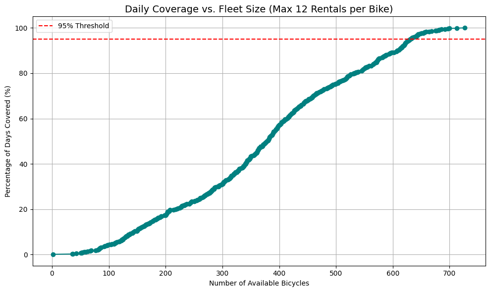

```python
import matplotlib.pyplot as plt

# Create sorted unique values of bikes needed
bikes_needed_sorted = np.sort(df['bikes_needed'].unique())
coverage = []

# For each possible fleet size, calculate % of days covered
for n in bikes_needed_sorted:
    days_covered = (df['bikes_needed'] <= n).sum()
    coverage.append(100 * days_covered / len(df))

# Plot
plt.figure(figsize=(10, 6))
plt.plot(bikes_needed_sorted, coverage, marker='o', color='teal')
plt.title("Daily Coverage vs. Fleet Size (Max 12 Rentals per Bike)", fontsize=14)
plt.xlabel("Number of Available Bicycles")
plt.ylabel("Percentage of Days Covered (%)")
plt.grid(True)
plt.axhline(95, color='red', linestyle='--', label='95% Threshold')
plt.legend()
plt.tight_layout()
plt.show()
```

## Part 3 - Building prediction models

**Tasks:**

1. Define a test metric for predicting the daily demand for bike sharing, which you would like to use to measure the accuracy of the constructed models, and explain your choice.
2. Build a demand prediction model with Random Forest, preferably making use of following python libraries: scikit-learn.
3. Report the value of the chosen test metric on the provided data.

**Answers / comments / reasoning:**

### **➡️ Part 3 - Task 1:** Evaluation metric

This is a **regression problem** as we are predicting a continuous numerical value (the number of bike rentals per day). The appropriate evaluation metric in this case could be **Root Mean Squared Error (RMSE)**, which measures the square root of the average squared difference between predicted and actual values. RMSE is particularly suitable here because it penalizes larger errors more strongly, which is important in bike sharing operations where underestimating demand can lead to a shortage of available bikes, and overestimating can result in unnecessary operational costs. The formula for RMSE is:

$$ \text{RMSE} = \sqrt{ \frac{1}{n} \sum_{i=1}^{n} (y_i - \hat{y}_i)^2 } $$

where $y_i$ is the actual number of rentals, $\hat{y}_i$ is the predicted number, and $n$ is the total number of days. RMSE is expressed in the same units as the target variable (number of rentals), making it directly interpretable and useful for real-world decisions. Other metrics like MAE (Mean Absolute Error) do not penalize large errors as strongly, which can hide the impact of underpredicting on peak days. MAPE (Mean Absolute Percentage Error) is unreliable when the actual number of rentals is small, leading to instability or division by zero. R² score, while useful for measuring variance explained, is harder to interpret operationally and does not give insight into the magnitude of the prediction error. Therefore, RMSE seems to be the most effective metric for evaluating the accuracy of bike rental demand models in this context.

However, in addition to **RMSE**, we use other metrics like **MAE** and **R² Score** because each one highlights a different aspect of model performance, giving a more complete evaluation.

**RMSE** (Root Mean Squared Error) gives more weight to large errors, which is useful when big mistakes are particularly costly — like on peak demand days. However, it can be overly sensitive to outliers.

**MAE** (Mean Absolute Error) provides the average magnitude of errors in a more balanced way, treating all errors equally regardless of size. It is more robust to outliers and easier to interpret: “on average, we're off by X bikes.”

**R² Score** (Coefficient of Determination) tells us how much of the variation in bike demand is explained by the model. A value close to 1 indicates the model explains most of the variability, while a value near 0 means it explains very little.

Using all three helps us understand:

- how far off we are on average (MAE),
- whether we make any major errors (RMSE),
- and how well our model fits the data (R²).

### **➡️ Part 3 - Task 2:** Demand prediction with Random Forest model

```python
from sklearn.ensemble import RandomForestRegressor
from sklearn.metrics import mean_squared_error, mean_absolute_error, r2_score
from sklearn.preprocessing import StandardScaler

# Loading data
df = pd.read_csv('day.csv')
df['dteday'] = pd.to_datetime(df['dteday'])
df = df.sort_values('dteday')

# Use only numerical and categorical features (drop id, date, and target-related columns)
features = df.drop(columns=['instant','dteday', 'cnt', 'casual', 'registered'])
target = df['cnt']

# Split into train and test based on last 30 days
X_train, X_test = features.iloc[:-30], features.iloc[-30:]
y_train, y_test = target.iloc[:-30], target.iloc[-30:]

# Train Random Forest model
model = RandomForestRegressor(n_estimators=100, random_state=42)
model.fit(X_train, y_train)

# Predict
y_pred = model.predict(X_test)
```

### **➡️ Part 3 - Task 3:** Evaluation report

```
📊 RMSE: 1108.90
📊 MAE: 865.88
📊 R² Score: 0.616
```

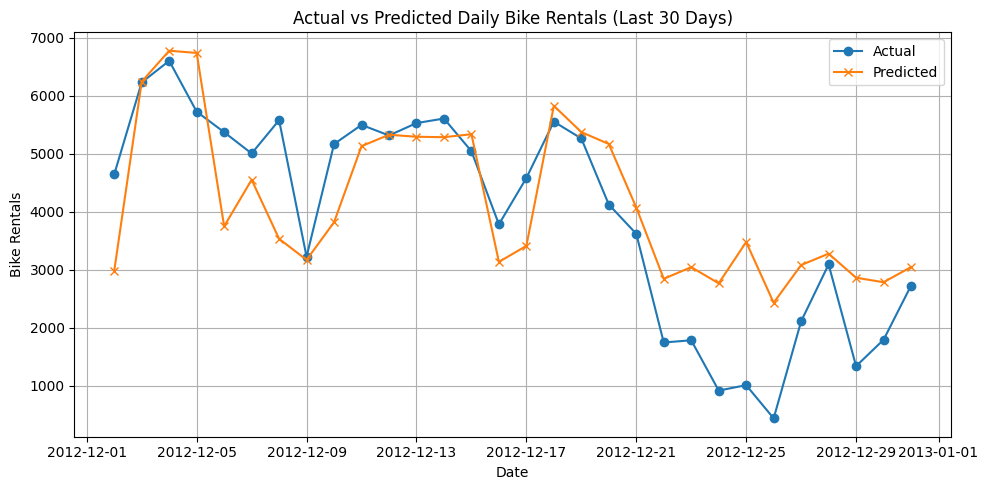

```python
# Evaluate
rmse = np.sqrt(mean_squared_error(y_test, y_pred))
mae = mean_absolute_error(y_test, y_pred)
r2 = r2_score(y_test, y_pred)

print(f"📊 RMSE: {rmse:.2f}")
print(f"📊 MAE: {mae:.2f}")
print(f"📊 R² Score: {r2:.3f}")

# Plot predictions vs actual
plt.figure(figsize=(10, 5))
plt.plot(df['dteday'].iloc[-30:], y_test.values, label='Actual', marker='o')
plt.plot(df['dteday'].iloc[-30:], y_pred, label='Predicted', marker='x')

plt.title("Actual vs Predicted Daily Bike Rentals (Last 30 Days)")
plt.xlabel("Date")
plt.ylabel("Bike Rentals")
plt.legend()
plt.grid(True)
plt.tight_layout()
plt.show()
```

## **✨ Enhancing the prediction performance (beyond the defined task) ✨**

The initial Random Forest model trained to predict daily bike rental demand achieves an **RMSE of 1108.90**, **MAE of 865.88**, and an **R² score of 0.616** on the test set of the last 30 days. While the model captures general trends in demand, the relatively modest R² score and visible divergence between predicted and actual values indicate that there is **room for improving predictive accuracy**.

In the following sections, we enhance the model through several strategies. First, we apply **feature engineering**, including the incorporation of **look-back (lag) features**, which introduce temporal dependency essential for modeling time series effectively. We also consider examining **feature importance** to remove irrelevant variables and engineer more meaningful ones. Next, we address model performance through **hyperparameter tuning** to optimize the behavior of the Random Forest.

Furthermore, since Random Forest is not inherently designed for temporal data, we expand our analysis by exploring **alternative models** such as **gradient boosting methods (e.g., XGBoost, LightGBM)** and **deep learning approaches (like LSTM)** that are often more suited for capturing sequential patterns. These extensions are aimed at building a more robust, accurate model for real-world bike demand forecasting.

## **⚙️ Feature Engineering**

### 👁‍🗨 Adding a **look-back feature**

to include the effect of previous days' bike rentals in predicting today’s demand.

```
📅 Look-back window: 1 day(s)
   RMSE: 885.73, MAE: 697.26, R²: 0.755

📅 Look-back window: 3 day(s)
   RMSE: 908.29, MAE: 754.88, R²: 0.742

📅 Look-back window: 7 day(s)
   RMSE: 926.14, MAE: 754.79, R²: 0.732
```

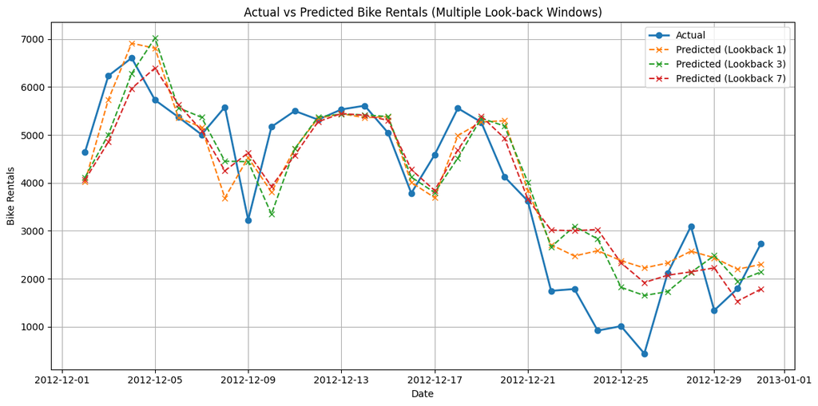

```python
def add_lookback_features(df, lags):
    df = df.copy()
    for lag in range(1, lags + 1):
        df[f'lag_{lag}'] = df['cnt'].shift(lag)
    df.dropna(inplace=True)
    return df

# ----------- Combined Evaluation & Plotting -----------
def evaluate_multiple_lookbacks(df, lookback_list):
    df['dteday'] = pd.to_datetime(df['dteday'])
    df = df.sort_values('dteday')

    plt.figure(figsize=(12, 6))
    actual_plotted = False

    for lookback in lookback_list:
        df_lagged = add_lookback_features(df, lookback)

        features = df_lagged.drop(columns=['instant','dteday', 'cnt', 'casual', 'registered'])
        target = df_lagged['cnt']

        X_train = features.iloc[:-30]
        X_test = features.iloc[-30:]
        y_train = target.iloc[:-30]
        y_test = target.iloc[-30:]
        dates_test = df_lagged['dteday'].iloc[-30:]

        model = RandomForestRegressor(n_estimators=100, random_state=42)
        model.fit(X_train, y_train)
        y_pred = model.predict(X_test)

        rmse = np.sqrt(mean_squared_error(y_test, y_pred))
        mae = mean_absolute_error(y_test, y_pred)
        r2 = r2_score(y_test, y_pred)

        print(f"📅 Look-back window: {lookback} day(s)")
        print(f"   RMSE: {rmse:.2f}, MAE: {mae:.2f}, R²: {r2:.3f}\n")

        if not actual_plotted:
            plt.plot(dates_test, y_test.values, label='Actual', marker='o', linewidth=2)
            actual_plotted = True

        plt.plot(dates_test, y_pred, label=f'Predicted (Lookback {lookback})', marker='x', linestyle='--')

    plt.title("Actual vs Predicted Bike Rentals (Multiple Look-back Windows)")
    plt.xlabel("Date")
    plt.ylabel("Bike Rentals")
    plt.legend()
    plt.grid(True)
    plt.tight_layout()
    plt.show()

# ----------- Run for multiple lookbacks -----------
evaluate_multiple_lookbacks(df, [1, 3, 7])
```

Adding a look-back feature significantly impacts the model's performance. Introducing a **1-day look-back** sharply improved the results, reducing the RMSE and MAE to **885.73** and **697.26**, respectively, and raising the R² to **0.755**, showing that immediate past values are highly predictive of current demand. A **3-day look-back** slightly worsened performance compared to the 1-day version but still outperformed the original model significantly, while a **7-day look-back** further reduced performance, likely due to overfitting or diminished relevance of older data.

These results suggest that while incorporating temporal context via lag features is clearly beneficial, **adding too many past days may dilute predictive power or introduce noise**. Therefore, to strike a balance between model complexity and performance, we proceed using the **1-day look-back window** as the most effective setup for this Random Forest model.

```python
# Create 1-day lag feature
df_lagged = df.copy()
df_lagged['cnt_lag_1'] = df_lagged['cnt'].shift(1)
df_lagged.dropna(inplace=True)

# Define features and target
X = df_lagged.drop(columns=['instant', 'dteday', 'cnt', 'casual', 'registered'])
y = df_lagged['cnt']

# Train/test split (last 30 days as test)
X_train, X_test = X[:-30], X[-30:]
y_train, y_test = y[:-30], y[-30:]

# Train and predict
model = RandomForestRegressor(random_state=42)
model.fit(X_train, y_train)
y_pred = model.predict(X_test)

# Evaluate
rmse = np.sqrt(mean_squared_error(y_test, y_pred))
mae = mean_absolute_error(y_test, y_pred)
r2 = r2_score(y_test, y_pred)
print(f"RMSE: {rmse:.2f}, MAE: {mae:.2f}, R²: {r2:.3f}")
```

```
RMSE: 885.73, MAE: 697.26, R²: 0.755
```

### **Feature importance**

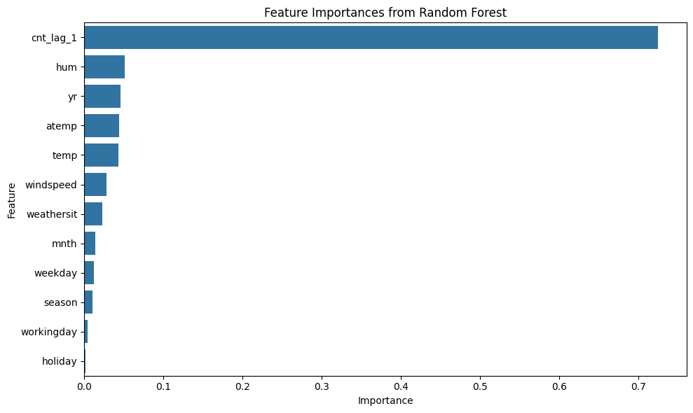

```python
import seaborn as sns

# Get feature importances
importances = model.feature_importances_
feature_names = X_train.columns

# Create a DataFrame for better visualization
importance_df = pd.DataFrame({
    'Feature': feature_names,
    'Importance': importances
}).sort_values(by='Importance', ascending=False)

# Plot the top N features
plt.figure(figsize=(10, 6))
sns.barplot(x='Importance', y='Feature', data=importance_df)
plt.title('Feature Importances from Random Forest')
plt.tight_layout()
plt.show()
```

The feature importance results strongly highlight the dominance of **`cnt_lag_1`**, which holds an importance score of **0.724**, indicating that yesterday’s rental count is by far the most predictive feature for today’s rental demand. This makes intuitive sense, as bike usage tends to follow short-term temporal patterns influenced by user habits and persistent weather trends.

Following that, **`hum`** (humidity), **`yr`** (year), **`atemp`** (feels-like temperature), and **`temp`** (actual temperature) have modest contributions, each ranging between **0.04–0.05** in importance. These weather-related and temporal features reflect their secondary influence on rental behavior, showing that while environment matters, it's not as directly influential as recent demand.

Less influential features include **`windspeed`**, **`weathersit`**, and **`mnth`**, which contribute smaller amounts. This suggests that while weather type and seasonal context play a role, their effects may already be captured indirectly through temperature and lagged demand.

Features like **`workingday`**, **`weekday`**, **`season`**, and especially **`holiday`** have the lowest importance. This implies that once more directly relevant features are accounted for, the presence of a holiday or whether it’s a weekend adds little to the model's predictive power in this context.

### **Hyperparameter tuning**

```python
from sklearn.model_selection import RandomizedSearchCV

import warnings
warnings.filterwarnings('ignore')

# Define parameter grid
param_dist = {
    'n_estimators': [100, 200, 300],
    'max_depth': [None, 10, 20, 30],
    'min_samples_split': [2, 5, 10],
    'min_samples_leaf': [1, 2, 4],
    'max_features': ['auto', 'sqrt', 'log2']}

# Set up the randomized search
search = RandomizedSearchCV(
    RandomForestRegressor(random_state=42),
    param_distributions=param_dist,
    n_iter=20,
    cv=3,
    scoring='neg_root_mean_squared_error',
    random_state=42,
    n_jobs=-1)

# Fit to training data
search.fit(X_train, y_train)

# Best model and score
print("Best params:", search.best_params_)
print("Best RMSE:", -search.best_score_)
```

```
Best params: {'n_estimators': 300, 'min_samples_split': 5, 'min_samples_leaf': 1, 'max_features': 'log2', 'max_depth': 30}
Best RMSE: 980.0909576610862
```

## **Training with other models**

```
1/1 ━━━━━━━━━━━━━━━━━━━━ 0s 181ms/step
XGBoost -> RMSE: 908.27, MAE: 664.69, R²: 0.742
LightGBM -> RMSE: 891.02, MAE: 692.92, R²: 0.752
LSTM -> RMSE: 780.73, MAE: 648.60, R²: 0.810
```

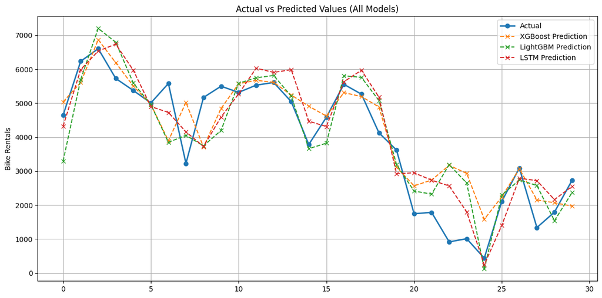

```python
import xgboost as xgb
import lightgbm as lgb
import tensorflow as tf
from tensorflow.keras.models import Sequential
from tensorflow.keras.layers import LSTM, Dense
from sklearn.preprocessing import StandardScaler

# ----------- XGBoost -----------
xgb_model = xgb.XGBRegressor(random_state=42, n_estimators=200)
xgb_model.fit(X_train, y_train)
y_pred_xgb = xgb_model.predict(X_test)

# ----------- LightGBM -----------
lgb_model = lgb.LGBMRegressor(random_state=42, n_estimators=200, verbosity=-1)
lgb_model.fit(X_train, y_train)
y_pred_lgb = lgb_model.predict(X_test)

# ----------- LSTM -----------
# For LSTM, data must be 3D: (samples, timesteps, features)
# We'll reshape X_train and X_test assuming timesteps=1 for simplicity
scaler_X = StandardScaler()
scaler_y = StandardScaler()

X_train_scaled = scaler_X.fit_transform(X_train)
X_test_scaled = scaler_X.transform(X_test)
y_train_scaled = scaler_y.fit_transform(y_train.values.reshape(-1, 1))
y_test_scaled = scaler_y.transform(y_test.values.reshape(-1, 1))

X_train_lstm = X_train_scaled.reshape((X_train_scaled.shape[0], 1, X_train_scaled.shape[1]))
X_test_lstm = X_test_scaled.reshape((X_test_scaled.shape[0], 1, X_test_scaled.shape[1]))

lstm_model = Sequential([
    LSTM(50, activation='relu', input_shape=(1, X_train_scaled.shape[1])),
    Dense(1)])

lstm_model.compile(optimizer='adam', loss='mse')
lstm_model.fit(X_train_lstm, y_train_scaled, epochs=20, batch_size=32, verbose=0)

y_pred_lstm_scaled = lstm_model.predict(X_test_lstm)
y_pred_lstm = scaler_y.inverse_transform(y_pred_lstm_scaled).flatten()

# ----------- Combined Evaluation & Plot Function -----------
def evaluate_and_plot_combined(y_true, predictions_dict):
    plt.figure(figsize=(12, 6))

    # Plot actual values
    plt.plot(y_true.values, label='Actual', marker='o', linewidth=2)

    # Loop through model predictions and compute metrics
    for model_name, y_pred in predictions_dict.items():
        rmse = np.sqrt(mean_squared_error(y_true, y_pred))
        mae = mean_absolute_error(y_true, y_pred)
        r2 = r2_score(y_true, y_pred)
        print(f"{model_name} -> RMSE: {rmse:.2f}, MAE: {mae:.2f}, R²: {r2:.3f}")

        plt.plot(y_pred, label=f'{model_name} Prediction', marker='x', linestyle='--')

    plt.title("Actual vs Predicted Values (All Models)")
    # plt.xlabel("Date")
    plt.ylabel("Bike Rentals")
    plt.legend()
    plt.grid(True)
    plt.tight_layout()
    plt.show()

# ----------- Usage -----------
predictions = {
    'XGBoost': y_pred_xgb,
    'LightGBM': y_pred_lgb,
    'LSTM': y_pred_lstm}

evaluate_and_plot_combined(y_test, predictions)
```

The results clearly indicate that the **LSTM model performs the best** among the four evaluated models. It achieves the **lowest RMSE** and **MAE**, and the **highest R² score**. This suggests that the LSTM model captures the underlying structure of the data more effectively than the tree-based models, likely because it can account for temporal dependencies or sequential patterns present in the dataset.

The **Random Forest** model shows relatively strong performance as well, with an **RMSE of 885.73**, **MAE of 697.26**, and **R² of 0.755**. These results indicate that it captures a good portion of the variance in the data, although it’s not as accurate as LSTM in terms of both average and squared error metrics.

**LightGBM** and **XGBoost** follow closely, with **R² scores of 0.752** and **0.742**, respectively. LightGBM has a slightly better RMSE (891.02) than XGBoost (908.27), while XGBoost has the lowest MAE (664.69) among the tree models, suggesting it may handle individual prediction errors better in some cases, despite a lower overall fit.

The difference in performance metrics, especially the higher R² and lower errors achieved by LSTM, points to the importance of modeling temporal structure if present in the dataset. In contrast, the tree-based models perform similarly and would be a solid alternative if model interpretability, simplicity, or lower computational cost is a priority.

## Part 4 - Reflection / comments

**Tasks:** (Optional) Please share with us any free form reflection, comments or feedback you have in the context of this test task.

**While the task was interesting and somewhat relevant to a Data Scientist position at SIXT, it offered limited scope to fully demonstrate the candidate's capabilities.** In particular, **Task 2 was quite straightforward**, and the dataset was already clean and free of missing or faulty values, which reduced the opportunity to show preprocessing skills. Similarly, **in the bike demand prediction task**, the use of a specific model was prescribed, leaving little room for model selection or experimentation.

Despite these constraints, **I made an effort to go beyond the outlined requirements wherever possible**. For example, in **Part 2 - Task 2**, I enriched the visualizations to provide deeper insights by incorporating contextual information such as weather and seasonality. In **Task 3**, I applied **feature engineering**, performed **hyperparameter tuning**, and experimented with **additional models** suited for time series forecasting to improve predictive performance.

Overall, although the task was an interesting case for general data science role, it **did not fully align with the job description I applied for**, especially since it **did not involve recommender systems**. However, I hope to have the opportunity to demonstrate my expertise in those areas during the upcoming technical interviews.

## Submission

Please submit this notebook with your developments in .ipynb and .html formats as well as your requirements.txt file.

## References

[1] Lichman, M. (2013). UCI Machine Learning Repository [http://archive.ics.uci.edu/ml]. Irvine, CA: University of California, School of Information and Computer Science.